# Reproducible Research: Course Project 1

## Loading and preprocessing the data

Unzip and load the data:

```r
unzip("activity.zip")
csvdata <- read.csv("activity.csv")
str(csvdata)
```

```
## 'data.frame':    17568 obs. of  3 variables:
##  $ steps   : int  NA NA NA NA NA NA NA NA NA NA ...
##  $ date    : chr  "2012-10-01" "2012-10-01" "2012-10-01" "2012-10-01" ...
##  $ interval: int  0 5 10 15 20 25 30 35 40 45 ...
```

Convert date field from characters to date class:

```r
csvdata[,"date"] <- as.Date(csvdata[,"date"])
class(csvdata$date)
```

```
## [1] "Date"
```

## What is mean total number of steps taken per day?

Calculate the Total Steps per day

```r
daily_steps <- tapply(csvdata$steps, csvdata$date, sum)
```

Histogram for total steps by day

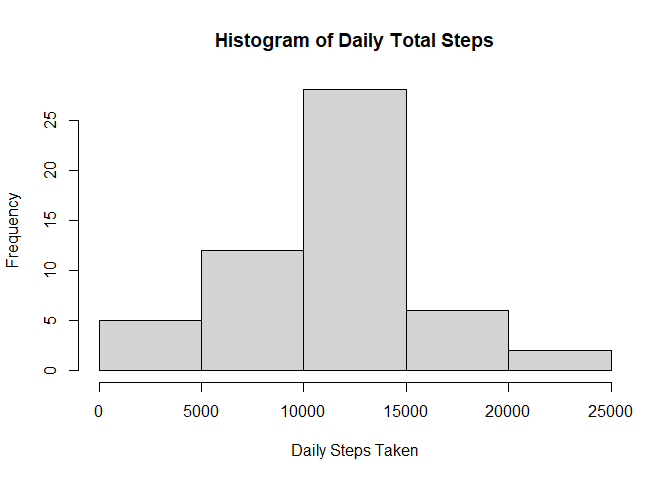

```r
hist(daily_steps, xlab = "Daily Steps Taken", main = "Histogram of Daily Total Steps")
```

Calculate mean and median steps per day

```r
mean(daily_steps, na.rm = T)
```

```
## [1] 10766.19
```

```r
median(daily_steps, na.rm = T)
```

```
## [1] 10765
```

## What is the average daily activity pattern?

Create a time series plot with 5 minute interval on the x-axis and average number of steps taken, averaged across all days (y-axis):

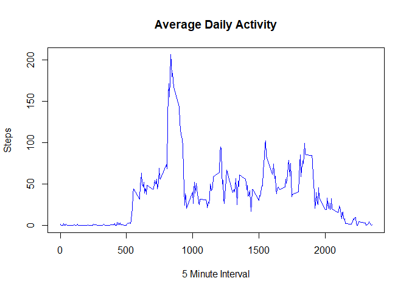

```r
interval_steps <- tapply(csvdata$steps, csvdata$interval, mean, na.rm = T)
interval <- as.numeric(names(interval_steps))

plot(interval, interval_steps,
     type = "l",
     col = "blue",
     lwd = 1.9,
     xlab = "5 Minute Interval",
     ylab = "Steps",
     main = "Average Daily Activity")
```

Which 5 minute interval contains the maximum number of steps?

```r
maxinterval <- subset(interval_steps, interval_steps == max(interval_steps))
paste("The interval with max number of steps is:", names(maxinterval))
```

```
## [1] "The interval with max number of steps is: 835"
```

## Imputing missing values

Check how many NAs there are per column with summary

```r
summary(csvdata)
```

```
##      steps             date               interval
##  Min.   :  0.00   Min.   :2012-10-01   Min.   :   0.0
##  1st Qu.:  0.00   1st Qu.:2012-10-16   1st Qu.: 588.8
##  Median :  0.00   Median :2012-10-31   Median :1177.5
##  Mean   : 37.38   Mean   :2012-10-31   Mean   :1177.5
##  3rd Qu.: 12.00   3rd Qu.:2012-11-15   3rd Qu.:1766.2
##  Max.   :806.00   Max.   :2012-11-30   Max.   :2355.0
##  NA's   :2304
```

```r
na_total <- sum(is.na(csvdata$steps))
```

*Steps* is the only variable to have NAs. **There are 2304 NA values**

```r
# convert our previous calculation of interval step averages into a data frame
interval_df <- data.frame(interval_steps)
interval_df$interval <- rownames(interval_df)
names(interval_df) <- c("avg_steps", "interval")

# merge the data into one dataset
activity <- merge(csvdata, interval_df, by = "interval", all = T)

# finds the indices of all nas
nas <- which(is.na(activity$steps))

# loop through all the NA values and replace it with the corresponding average value by date
for(i in nas){
        activity$steps[[i]] <- activity$avg_steps[[i]]

}

# remove the extra column
activity <- subset(activity, select = -avg_steps)
```

Replot histogram for total steps by day with imputed data

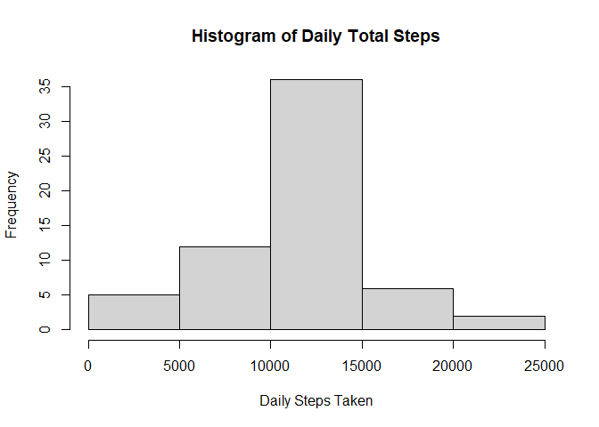

```r
d_steps <- tapply(activity$steps, activity$date, sum)
hist(d_steps, xlab = "Daily Steps Taken", main = "Histogram of Daily Total Steps")
```

Calculate mean and median steps per day

```r
mean(d_steps)
```

```
## [1] 10766.19
```

```r
median(d_steps)
```

```
## [1] 10766.19
```

## Are there differences in activity patterns between weekdays and weekends?

Create new factor variable indicating if the date is a weekday or weekend

```r
activity$day <- weekdays(activity$date)
activity$day <- factor(activity$day,
                       levels = c("Monday", "Tuesday", "Wednesday", "Thursday", "Friday", "Saturday", "Sunday"),
                       labels = c(rep("weekday",5),rep("weekend",2)))

head(activity)
```

```
##   interval    steps       date     day
## 1        0 1.716981 2012-10-01 weekday
## 2        0 0.000000 2012-11-23 weekday
## 3        0 0.000000 2012-10-28 weekend
## 4        0 0.000000 2012-11-06 weekday
## 5        0 0.000000 2012-11-24 weekend
## 6        0 0.000000 2012-11-15 weekday
```

Make a panel plot containing a time series plot of the 5-minute interval (x-axis) and the average number of steps taken, averaged across all weekday days or weekend days (y-axis)

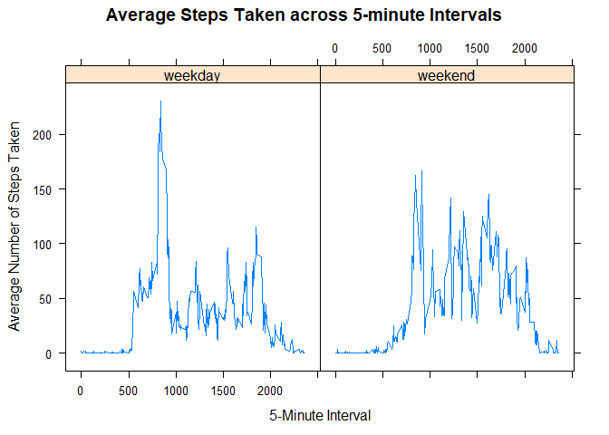

```r
library(lattice)

# group the data by interval and day and average the steps taken
activity2 <- aggregate(steps~interval + day, activity, mean)

# plot the graph using lattice plot
xyplot(steps ~ interval | day, data=activity2,
       type = 'l',
       main="Average Steps Taken across 5-minute Intervals",
       xlab="5-Minute Interval",
       ylab="Average Number of Steps Taken")
```

**Are there differences in patterns?** There seems to more overall average activity during the weekend than weekdays, however weekdays have a higher maximum peak movement during one of its days